# Applied Machine Learning with R

March 28, 2019

## Algorithms - Part 02

## Tree-Based Models

- These involving *stratifying* the predictor space;
- Rule to prediction: use the **mean** or **mode**;
- These types of approaches are known as *decisions tree* methods;
- Decision trees are **simple** and useful for **interpretations**;
- **Bagging**, **Random Forest** and **Boosting**;

[figure not shown]

## Tree-based Models: Decision Trees

- Decision Tree can be applied to **regression** and **classification**;
- The process of building a *regression* tree comprises two steps:
1. Divide the predictor space into \(J\) distinct and non-overlapping regions \(R_1, R_2, ..., R_J\);
2. For every *obs* that falls into the region \(R_j\), we make the same prediction;

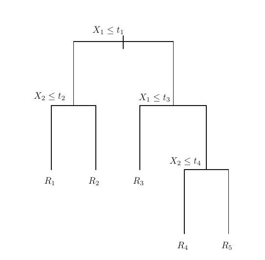

## Tree-based Models: Decision Trees

- How do we contruct the \(R_1, ..., R_J\)?
- The goal is to find \(R_1, ..., R_J\) such as \[ min \sum_{j = 1}^J \sum_{i \in R_j} (y_i - \hat{y}_{R_j})^2 \]
- Unfortunately, it is **computationally infeasible**;
- Better approach: *top-down*, *greedy* approach known as **recursive binary splitting**;

[figure not shown]

## Tree-based Models: Decision Trees

- **Recursive binary splitting**:
  - *top-down* beacuse it begins at the top of the three;
  - *greddy* because at each step the *split* is made at that particular step;
- The algorithm:
1. Select the predictor \(X_j\) and the cutpoint \(s\);
2. Split the predictor space in **two regions** \[ R_1 = \{X|X_j \lt s\} \quad\text{and}\quad R_2 = \{X|X_j \lt s\} \] such as leads to the greatest reduction in \[ \sum_{i : x_i \in R_1} (y_i - \hat{y}_{R_1})^2 + \sum_{i : x_i \in R_2} (y_i - \hat{y}_{R_2})^2 \]
3. Repeat the above process but this time using the identified regions;
4. The process continues until a stopping criteria is reached.

## Tree-based Models: Decision Tree

- The process described may produce very good prediction on the training set;
- Likely to overfit the test set;
- Possible alternative: build the tree so long as the decrease in RSS exceeds some threshold;
- That is, grow a very large tree \(T_0\) and then **prune** it back to obtain a *subtree* \(T\);
- **Cost complexity prunning** solves our problem;
- Consider a sequence of trees indexed by a tunning parameter \(\alpha\);
- For each value of \(\alpha\) there correspond a subtree \(T \subset T_0\) such that

\[ \sum_{m = 1}^T \sum_{i: x_i \in R_m}(y_i - \hat{y}_{R_m})^2 + \alpha|T| \] is a small as possible;

- \(\alpha\) is a **tunning parameter** controlling the trade-off between subtree’s complexity and fit to the dataset.

## Tree-based Models: Decision Tree

- The Final Algorithm:
1. Use **recursive binary splitting** to grow a large tree;
2. Apply **Cost complexity prunning** in order to obtain a subtree as a function of \(\alpha\);
3. Repeat Steps 1 and 2 for different values of \(\alpha\);
4. Return the subtree from Step 3 that gives the best out-of-sample performance.

## Tree-based Models: Decision Tree

- What about **classification** settings?
- Almost the same process. In general, two different things:
1. prediction: **majority vote**;
2. Loss function: not RSS anymore;
- Classification error rate: \[E = 1 - max_k(\hat{p}_{mk})\]
- Gini Index: \[G = \sum_{k = 1}^K\hat{p}_{mk}(1 - \hat{p}_{mk})\]
- Cross-entropy: \[ D = - \sum_{k = 1}^K \hat{p}_{mk}\log\hat{p}_{mk} \]

## Tree-based Models: Bagging

- Remember that *decision trees* suffer from **high variance**;
- Some of the most important properties an estimator can enjoy are:
  - **Unbiasedness**: \(E(\hat{\theta}) = \theta\)
  - **Consistency**: \(\hat{\theta} \stackrel{p}{\longrightarrow} \theta\)

## Tree-based Models: Bagging

- **The Weak Law of Large Numbers**:

Let \(Z_1, ..., Z_B\) a *iid* sequence of random variables and such as \(E(Z_t) = \mu\) and \(var(Z_t) = \sigma^2 < \infty\). Let \(\overline{Z_B} = B^{-1} \sum_{b=1}^B Z_b\) be an estimator for the unknown \(\mu\).

\[ \lim_{B \rightarrow \infty} E(\overline{Z_B}) = \frac{1}{B} \sum_{b = 1}^T \mu = \mu \] and

\[ \lim_{B \rightarrow \infty} var(\overline{Z_B}) = \lim_{B \rightarrow \infty} B^{-2}\sum_{b = 1}^T var(Z_b) = B^{-2} \sigma^2 \rightarrow 0 \] then,

\[ \overline{Z_B} = \frac{1}{B} \sum_{b = 1}^T Z_b \stackrel{p}{\longrightarrow} \mu. \]

## Tree-based Models: Bagging

- That’s when **bootstrap** comes at hand!!;
- *Bootstrap* is an extremely powerful idea;
- It is a computer-based method for assessing the accuracy of statistical estimates;
- Main Idea:
1. Treat the data as if they were the (true, unknown) population;
2. Draw sample (with replacement) from the data;
3. Repeate the procedure \(B\) times, each time computing the quantity of **interest**;
4. Use the \(B\) values to estimate its unknown distribution;
- **Boostratp aggregation** or **bagging** is a general purpose procedure for reducing the variance;
- In other words, we could calculate \(\hat{f}_1(x), \hat{f}_2(x), ..., \hat{f}_B(x)\) using \(B\) training sets then average the resulting predictions;
- Bagging has been demonstrated by give impressive improvements performance over individual decision trees;

## Tree-based Models: Random Forest

- Random Forest provides an improvement over bagged trees;
- Small tweak that **decorrelates** the trees;
- When building decision tree, a **random sample of** \(m\) **predictors**;
- Typicall we choose \(m \approx \sqrt{P}\);
- In other words, at each split in the tree the algorith is not even allowed to consider all \(P\);
- Rationale:
  - Suppose there is one very predictor, along with number of moderately ones;
  - Then, in the collection of bagged, most or all of trees will use this strong predictor;
  - As a result, the predictions will be highly correlated;
  - Unfornately, averaging many highly correlated trees does not lead to large reduction in variance;
- Random Forest forces each split to consider only a subset of the predictors;
- The main difference between *Bagging* and *Random Forest* is the choice of \(m\);
- \(m\) is **tunning parameter**.

## Tree-based Models: Boosting

- **Boosting** is a general approach;
- *Bagging* involves creating multiple copies of data using *bootstrap*, fitting a separete tree and then combining them by averaging;
- In *Boosting*, trees are grown **sequentially**: each tree is grown using information from previously tree;
- *Boosting* **DOES NOT** involve *bootstrap*. Rather, each tree is fit on a modified version of training data;
- The idea of *Boosting* is to combine several weak learners into a stronger one;

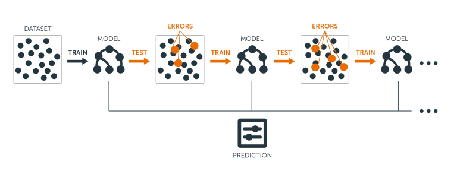

## Tree-based Models: Boosting

- *Boosting* algorithm:
1. Set \(\hat{f}(x) = 0\) and \(\epsilon_i = y_i\) for all \(i\) in training set;
2. For \(b = 1, ..., B\), repeat:
   1. Fit a tree \(\hat{f}^b\) to the training set \((X, \epsilon)\);
   2. Update \(\hat{f}\) by adding in a **shruken** version of the new tree: \[ \hat{f}(x) \longleftarrow \hat{f}(x) + \lambda\hat{f}^b(x) \]
   3. Update the residuals: \[ \epsilon_i \longleftarrow \epsilon_i - \lambda\hat{f}^b(x_i) \]
3. Output the boosted model: \[ \hat{f}(x) = \sum_{b = 1}^B \lambda \hat{f}^b(x) \]

## Tree-based Models: Boosting

- The **boosting** approach learns **slowly**;

\[ \hat{f}(x) = \sum_{b = 1}^B \lambda \hat{f}^b(x) \]

- In general, algorithm that *learn slowly* tend to perform well;
- Unlike *bagging*, the number the construction of tree depends strongly on \(B\);
- In general, Boosting has three tunning parameters:
1. The number of trees \(B\): boosting can overfit if \(B\) is too large;
2. The shrinkage parameter \(\lambda\): this controls the rate at which boosting learns;
3. The number of \(d\) splits in each tree: this control the complexity of the tree.

## Tree-based Models: Boosting

- There are some boosting implementations:
1. **Adaptive Boosting (AdaBoost)**: this algorithm corrects its predecessor by increasing the weight of the misclassified training instances;
2. **Gradient Boosting (GBM)**: this method tries to fit the new predictor to the residual errors made by the previous predictor;
3. **XGboost**: this algorithm has high predictive power and is ten times faster than any other gradient boosting techniques;
4. **Lightgbm**: for datasets which are extremely large Light Gradient Boosting takes less time to run;
5. **Catboost**: improvements over some existing libraries;

## Support Vector Machine

- Support Vector Machine (SVM) is a generalization of a simple classifier: *maximal margin classifier*;
- SVM is an algorithm developed in the computer science communinity in 1990s;
- Based on **hyperplanes**;
- In a \(p\)-dimension, a *hyperplane* is a subspace of dimension \(p-1\);
- The mathematical definition of a *hyperplane*:

\[ \beta_0 + \beta_1 X_1 + ... + \beta_p X_p = 0 \quad (1) \]

- For any \(\mathbb{X} = (X_1, ..., X_p)^T\) for which equation (1) holds;
- Suppose \(X\) does does not satisfy (1):

\[ \beta_0 + \beta_1 X_1 + ... + \beta_p X_p > 0 \\ \beta_0 + \beta_1 X_1 + ... + \beta_p X_p < 0 \]

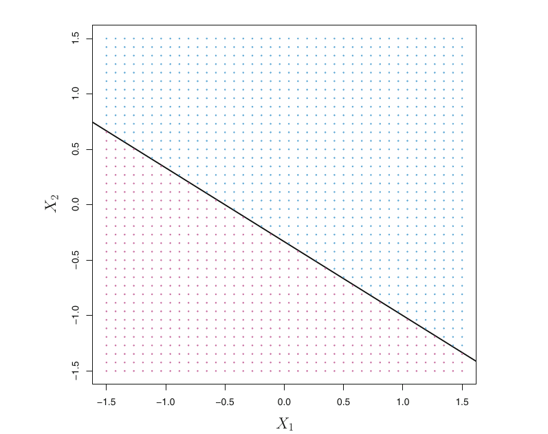

## Classification using Hyperplane

- Suppose \(\mathbb{X}\) with dimension \(N\)x\(P\) and \(Y = \{-1, 1\}\);
- Suppose that an **test** *obs* \(x^* = (x_1, ..., x_P)^T\);
- Suppose it is possible to construct a *hyperplane* separating training *obs* into classes;
- This separating hyperplane would have the following rule:

\[ \beta_0 + \beta_1 x_{i1} + ... + \beta_p x_{ip} > 0 \quad if \quad y_i = 1 \]

and

\[ \beta_0 + \beta_1 x_{i1} + ... + \beta_p x_{ip} < 0 \quad if \quad y_i = -1 \]

- Equivalent to:

\[ y_i(\beta_0 + \beta_1 x_{i1} + ... + \beta_p x_{ip}) > 0 \] - we classify the **test** obs \(x^*\) based on the sign of \(f(x^*)\):

\[ f(x^*) = \beta_0 + \beta_1 x^*_{i1} + ... + \beta_p x^*_{ip} \]

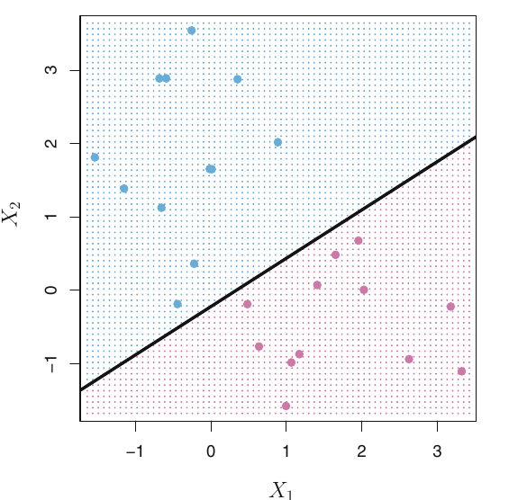

## Maximal Margin Classifier

- In general, if our data can be **perfectly separated** using a hyperplane;
- There will in fact exist an infinite number of such hyperplanes;

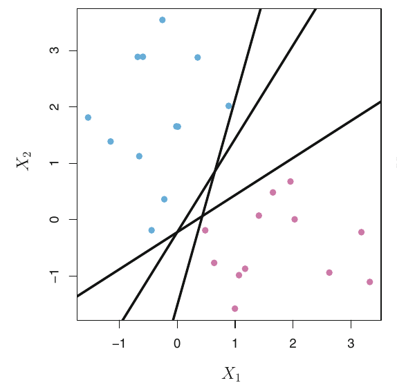

- *maximal margin hyperplane*: hyperplane that is farthest from the *training* obs;

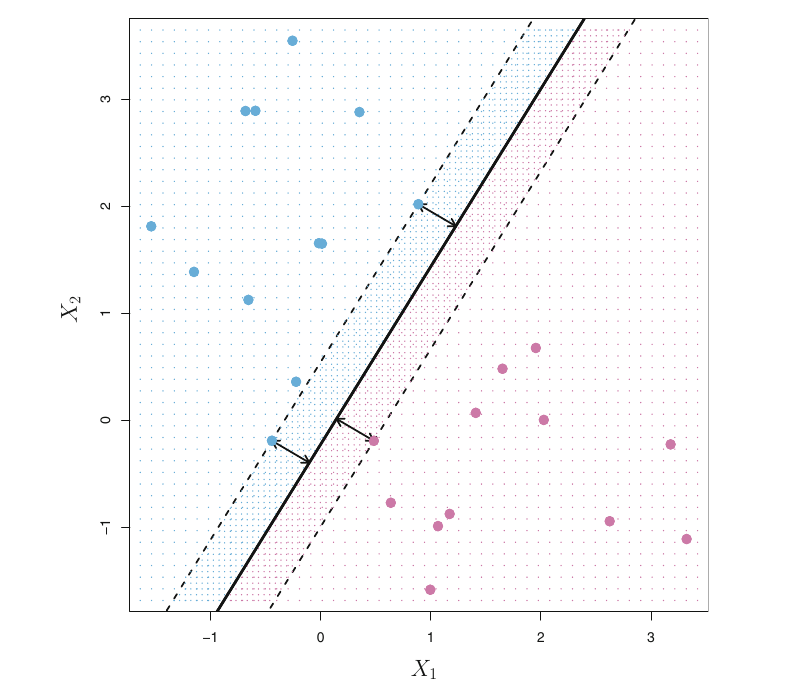

## Maximal Margin Classifier

- This is the **maximal margin Classifier**;

\[ \hat{\beta}_1, ..., \hat{\beta}_P = argmax_{\beta_1, ..., \beta_P} \quad M \\ \text{subject to} \sum_{j = 1}^P \beta_j^2 = 1 \\ y_i(\beta_0 + \beta_1 x_{i1} + ... + \beta_p x_{ip}) \ge M \\ \]

- Apply the rule based of the sign of  
  \[\hat{f}(x^*) = \hat{\beta}_0 + \hat{\beta}_1 x^*_{i1} + ... + \hat{\beta}_p x^*_{ip}\]

## Non-separable case

- *Maximal margin classifier* very simple, intuitive;
- **If a separating hyperplane exists**;

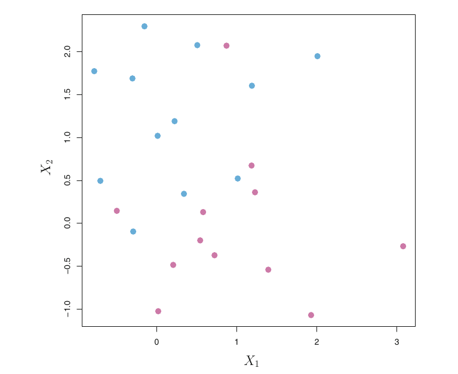

## Non-separable case

- Extend the idea of hyperplane that **almost** separate the classes;
- **Does NOT perfectly** separate the classes, in the interest of separate the **most**;
- The generalization of *maximal marging classifier* : **Support Vector Classifier**;
- Here, we allow some *obs* to be on the incorrect side of the marging, or even of the hyperplane;

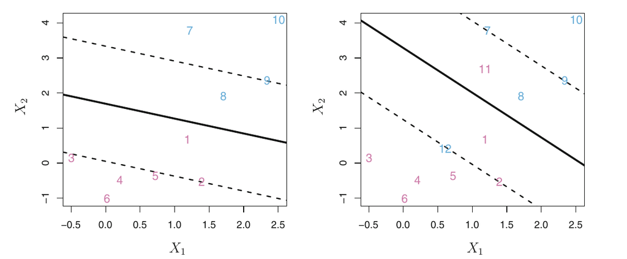

## Non-separable case

- The hyperplane is chosen as

\[ \hat{\beta}_1, ..., \hat{\beta}_P = argmax_{\beta_1, ..., \beta_P} \quad M \\ \text{subject to} \sum_{j = 1}^P \beta_j^2 = 1 \\ y_i(\beta_0 + \beta_1 x_{i1} + ... + \beta_p x_{ip}) \ge M(1 - \epsilon_i) \\ \epsilon_i \ge 0, \, \, \sum_{i = 1}^N \epsilon_i \le C \\ \]

**\(C\)** is a tunning parameters;

- Once we solved this problem, we classify the test obs based on the sign of \(\hat{f}(x^*)\);

## Non-separable case

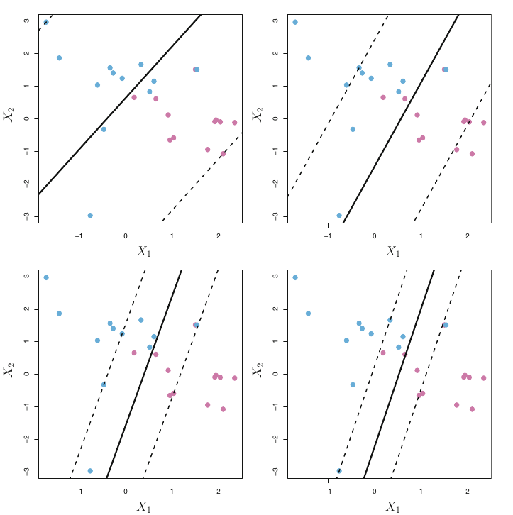

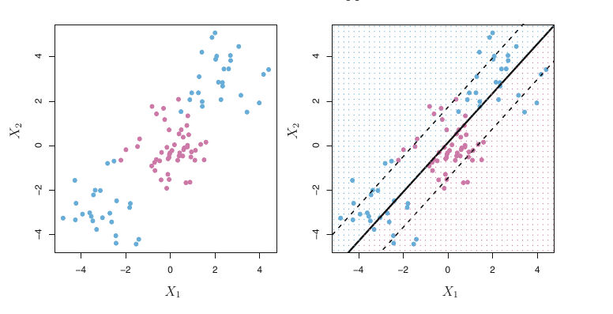

## Support Vector Machine

- SVC is good approach if the boundary between classes is **linear**;
- **Support Vector Machine (SVM)** is an extension of the SVC;
- An extension is due to enlarging the space using **Kernels**;
- The solution to previous optimizations problems involves **inner products** of *obs*;
- **Inner product**: \[ \langle x_i, x_{i^{'}} \rangle = \sum_{j=1}^P x_{ij} x_{i^{'}j} \]
- SVC can be represented as: \[ f(x) = \beta_0 + \sum_{i = 1}^N \alpha_i \langle x, x_i \rangle \]

## SVM

- Replace with a Kernel: \(K(x_i, x_{i^{'}j})\)
- **Polynomial Kernel** of degree \(d\) : \[ K(x_i, x_{i^{'}j}) = \left(1 + \sum_{j = 1}^P x_{ij} x_{i^{'}j}\right)^d \]
- **Radial Kernel**:

\[ K(x_i, x_{i^{'}j}) = \exp\left( - \gamma \sum_{j = 1}^P (x_{ij} - x_{i^{'}j})^2\right) \]

## Introduction to Deep Learning

[figure not shown]

## What is deep learning?

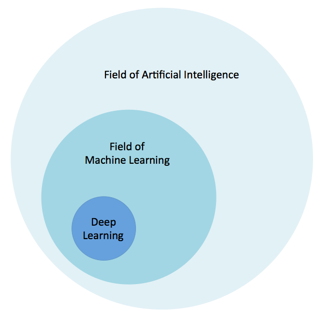

## What is deep learning?

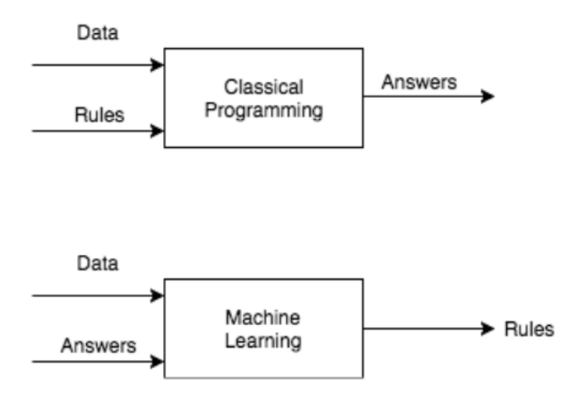

## The “*deep*” in deep learning

- Deep learning is a specific subfield of machine learning;
- The *deep* **is not** a reference to any king of deeper understand;
- It is an idea of **successive layers of representations**;
- These layered representations are learned via models called **neural network**;
- Deep learning models **ARE NOT** models of the brain;
- It is a mathematical framework for learning representation from data.

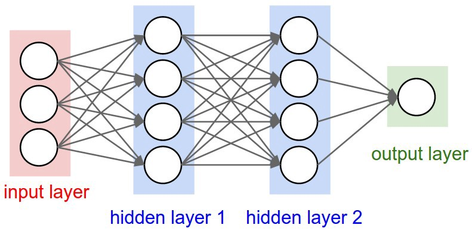

## Getting started with neural networks

- The anatomy of a Neural Network consisting in
1. **Input Layer**: That’s our matrix of features \(\mathbf{X}\);
2. **Hidden Layer**: The core building block. A data-processing module that you can think of as filter for data;
3. **Output Layer**: Here we finally map to the desired output format;
4. **Loss function**, which defines the feedback signal used for learning;
5. **Optimizer**, which determines how learning proceeds.

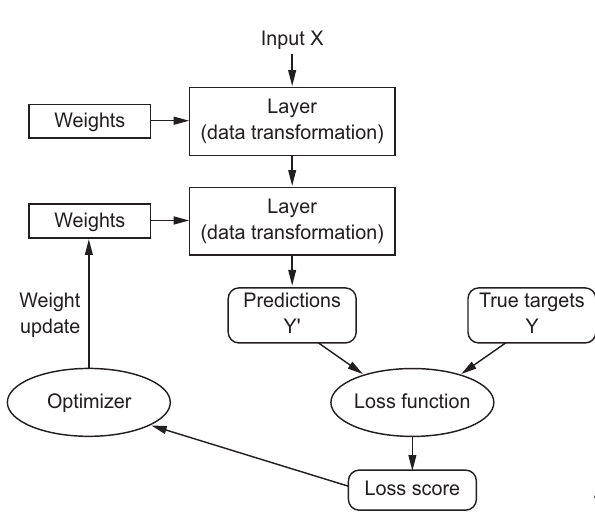

## Getting started with neural networks

- Formally, a simple neural network can be represented as:

\[ \left[\begin{array} {r} x_1 \\ x_2 \end{array}\right] \longrightarrow \left[\begin{array} {r} a_1^{(2)} \\ a_2^{(2)} \\ a_3^{(2)} \end{array}\right] \longrightarrow \left[\begin{array} {r} a_1^{(3)} \\ a_2^{(3)} \\ a_3^{(3)} \end{array}\right] \longrightarrow h_{\theta}(x) \] where \(a_i^{(j)}\) is the **activation unit** \(i\) in **layer** \(j\);

- Let \(\Theta^j\) the matrix of weights controling the mapping from layer \(j\) to layer \(j+1\)

\[ h_\Theta(x) = g(\Theta_{10}^{(3)}a_0^{(3)} + \Theta_{11}^{(3)}a_1^{(3)} + \Theta_{12}^{(3)}a_2^{(3)} + \Theta_{13}^{(3)}a_3^{(3)}) \\ \]

## Getting started with neural networks

- Common choices for *activation functions* are:
  - **Relu**: \(g(x) = \max(o, x)\);
  - **Sigmoid**: \(g(x) = \frac{1}{1 + e^{-x}}\);
  - **Tanh**: \(g(x) = \frac{2}{1 + e^{-2x}} - 1\)
- But, what are **activation functions** and why are they necessary?
- Without an activation function, the dense layer would consit of two linear operations;
- Hence, the hypothesis space would be the set of all possible *linear transformations*;
- In order to get access to much richer hypothesis space, we need some non-linearity.

## Getting started with neural networks

- The core building block of NN is the *layer*;
- Some data goes in, and it comes out in a more useful form;
- The matrix \(\Theta\) is responsible to map this transformation;
- But how do we estimate the weights \(\theta_{i}^{(j)}\)?
- **Back-propagation algorithm**:
1. Draw a *batch* of training samples \(X\) and corresponding \(y\);
2. Run the network on \(X\) (forward pass) to obtain predictions;
3. Compute the loss of the network on the *batch*;
4. Update all weights of the network in a way that reduces the loss on this batch (*backward pass*).
- Deep learning models has achieved an impressive performance in perceptual problems:
  - Near-human-level image classification;
  - Near-human-level speech classification;
  - Near-human-level handwritting transcription;
  - Near-human-level autonomous driving;
- Of course, Deep learning models are not always the best approach;
- Sometimes, the simpler the better;
- So, do not be that guy:

[figure not shown]

## Wrapup

**Any questions**?